# Applied Data Science @ Columbia

## Fall 2021

## Project 1: A “data story” on the history of philosophy

output=github_document

[figure not shown]

### Project Description

This is the first and only *individual* (as opposed to *team*) project this semester.

Term: Fall 2021

- Project title: Gender and Philosophy through the Ages
- This project is conducted by Dan Harvey | dyh2111@columbia.edu
- Project summary: As gender equality and respect of identity has become an important topic, I wanted to take a look at how gender plays a role in these philosopher’s minds and throughout the ages, so I wanted to answer these simple questions by evaluating our data set against masculine, feminine, and neutral gender pronouns and their occurrences throughout the ages and by author.

I found myself asking the following questions:

- Does the use of feminine pronouns increase as the years go by?
- Does the use of masculine pronouns decrease as the years go by?
- Are certain authors more likely to use feminine, masculine, or neutral pronouns?

## This folder is orgarnized as follows.

```
proj/
├── lib/
├── data/
├── doc/
├── figs/
└── output/
```

Please see each subfolder for a README file.

### Data Source

The data source that we used in this project was downloaded here on September 23,2021: https://www.kaggle.com/kouroshalizadeh/history-of-philosophy.

### Methodolgy

We divided pronouns into 3 categories:

- Feminine: she, her, hers, herself, female, girl, women, woman
- Masculine: him, he, his, himself, male, boy, men, man
- Neutral: them, they, their

We then took note to see how often they were used with each author in their texts in the data set and the amount these were used over the years.

### Findings

This report was prepared with the following environmental settings.

```r
print(R.version)
```

```
##                _
## platform       x86_64-apple-darwin17.0
## arch           x86_64
## os             darwin17.0
## system         x86_64, darwin17.0
## status
## major          4
## minor          1.1
## year           2021
## month          08
## day            10
## svn rev        80725
## language       R
## version.string R version 4.1.1 (2021-08-10)
## nickname       Kick Things
```

```r
# Load Libraries

library("tidyverse")
```

```r
library("readr")
library("ggplot2")
library("wordcloud2")
library("wordcloud")
library("tm")
library("plyr")
#Make sure your working directory is set
setwd("~/Documents/GitHub/Fall2021-Project1-DH2111")

#import raw data
philosophy_data <- read_csv("data/philosophy_data.csv",
    col_types = cols(title = col_skip(),
        sentence_spacy = col_skip(), sentence_str = col_skip(),
        corpus_edition_date = col_skip(),
        lemmatized_str = col_skip()))

#Set pronoun specifications
feminine  <- "she | her | hers | herself | female | girl | women | woman"
masculine <- "him | he | his | himself | male | boy | men | man"
neutral   <- "them | they | their"

#Subset data to only contain gender related
feminine_data<-philosophy_data%>%filter(grepl(feminine,sentence_lowered))
masculine_data<-philosophy_data%>%filter(grepl(masculine,sentence_lowered))
neutral_data<-philosophy_data%>%filter(grepl(neutral,sentence_lowered))

rowsByGender <- data.frame(Gender = c("Masculine", "Feminine", "Neutral"),
                 Entries = c(nrow(masculine_data), nrow(feminine_data), nrow(neutral_data)))
```

## Preliminary Overview

First, Lets take an overall look at how the Corpus with gender references are divided upon the 3 camps of gender references:

- Feminine
- Masculine
- Neutral

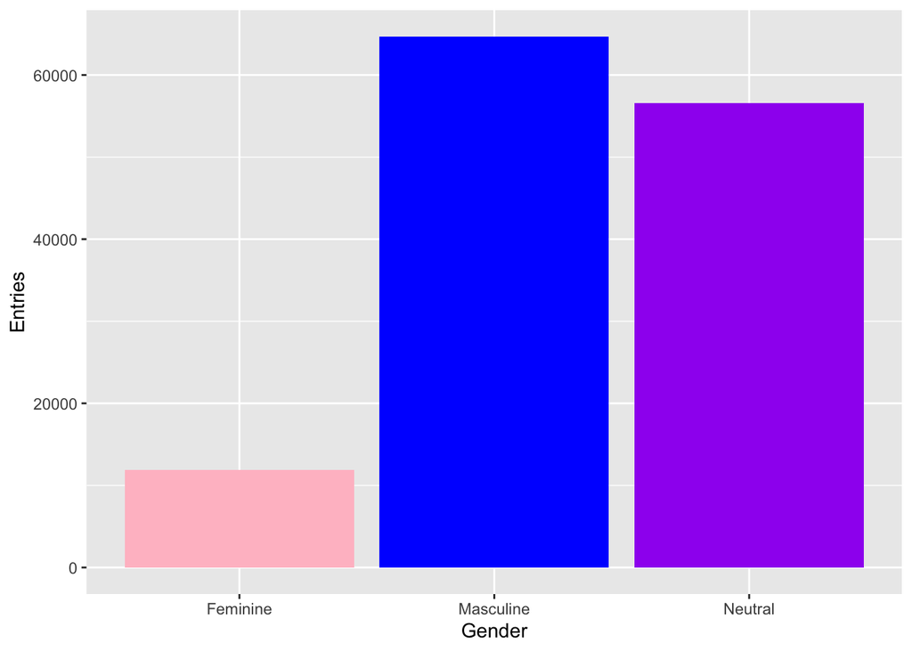

```r
ggplot(rowsByGender, aes(x=Gender, y = Entries)) +
  geom_bar(stat="identity", fill = c("blue", "pink", "purple"))
```

To get a visual idea of what pronouns are most dominant in these 3 camps, we will refer to these word clouds:

**Feminine References**

```r
feminineWordCount <- data.frame(Gender = c("she", "her", "hers", "herself" , "female",  "girl" , "women" , "woman"),
                 Entries = c(str_count(feminine_data[6],"she")
, str_count(feminine_data[6],"her")
, str_count(feminine_data[6],"hers")
, str_count(feminine_data[6],"herself")
, str_count(feminine_data[6],"female")
, str_count(feminine_data[6],"girl")
, str_count(feminine_data[6],"women")
, str_count(feminine_data[6],"woman")
))

wordcloud2(data = feminineWordCount, size=1)
```

[interactive chart not shown]

```r
feminineWordCount
```

```
##    Gender Entries
## 1     she    9035
## 2     her   16041
## 3    hers    1742
## 4 herself    1322
## 5  female    1092
## 6    girl     706
## 7   women    2995
## 8   woman    3823
```

Interestingly, we see find that “her” is used the most, almost double that of “she”.

**Masculine References**

```r
masculineWordCount <- data.frame(Gender = c("him", "he", "his","himself","male","boy","men","man"),
                 Entries = c( str_count(masculine_data[6],"him")
, str_count(masculine_data[6],"he")
, str_count(masculine_data[6],"his")
, str_count(masculine_data[6],"himself")
, str_count(masculine_data[6],"male")
, str_count(masculine_data[6],"boy")
, str_count(masculine_data[6],"men")
, str_count(masculine_data[6],"man")
))

wordcloud2(data = masculineWordCount, size=1)
```

[interactive chart not shown]

```r
masculineWordCount
```

```
##    Gender Entries
## 1     him   15760
## 2      he  286136
## 3     his   43188
## 4 himself    5649
## 5    male    2178
## 6     boy     479
## 7     men   20297
## 8     man   39539
```

Here, “he” is used the most, overwhelmingly more than “man”.

**Neutral References**

```r
neutralWordCount <- data.frame(Gender = c("them", "they", "their"),
                 Entries = c( str_count(neutral_data[6],"them")
, str_count(neutral_data[6],"they")
, str_count(neutral_data[6],"their")
))

wordcloud2(data = neutralWordCount, size=1)
```

[interactive chart not shown]

```r
neutralWordCount
```

```
##   Gender Entries
## 1   them   27288
## 2   they   43134
## 3  their   33192
```

With regard to the neutral terms, we see they are not as far off from each other as the gender specific references.

**Comparing the the frequency of individual Pronouns**

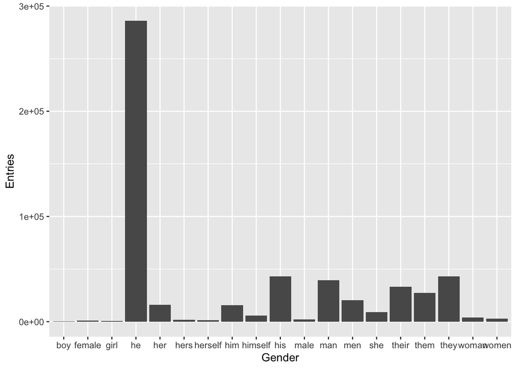

```r
combinedWordCounts <- rbind(neutralWordCount, masculineWordCount,feminineWordCount)

ggplot(combinedWordCounts, aes(x=Gender, y = Entries)) +
  geom_bar(stat="identity")
```

```r
combinedWordCounts
```

```
##     Gender Entries
## 1     them   27288
## 2     they   43134
## 3    their   33192
## 4      him   15760
## 5       he  286136
## 6      his   43188
## 7  himself    5649
## 8     male    2178
## 9      boy     479
## 10     men   20297
## 11     man   39539
## 12     she    9035
## 13     her   16041
## 14    hers    1742
## 15 herself    1322
## 16  female    1092
## 17    girl     706
## 18   women    2995
## 19   woman    3823
```